# Climate Change in Egypt: Temperature, Precipitation and Drought Trends

Till Meissner

2026-02-26

# Executive Summary

# Data and Methods

## Data Sources

- **Temperature Data**: ERA5 reanalysis (1960-2024) at daily resolution.
- **Precipitation Data**: CHIRPS (1981-2024) at daily resolution.
- **Agricultural Drought**: Remotely sensed data indicating vegetative stress (ESI, NDVI, EVI).
- **Population Data**: LandScan population distribution (2020).
- **Baseline Period**: 1960-2010 for temperature; 1981-2024 mean for precipitation.

## Weighting Methods

1. **Unweighted**: Simple spatial average across each governorate.
2. **Population-weighted**: Weighted by where people actually live within each governorate.,

Population weighting provides a more accurate representation of human exposure to climate changes.

# Population and Cropland Distribution

```r
#population palette
pal_pop <- colorNumeric(
  palette = "inferno",
  domain = log10(pop_2020_cropped_df$b1 + 1),
  na.color = "transparent")

#leaflet
leaflet() |>
  addProviderTiles(providers$CartoDB.Positron) |>
  addRasterImage(
    log10(pop_2020_cropped + 1),
    colors = pal_pop,
    opacity = 0.8,
    project = TRUE,
    group = "Population") |>
  addRasterImage(
    modis_lc_cropped,
    colors = c("#b2182b", "#238b45", "orange3"),
    opacity = 0.8,
    project = TRUE,
    group = "Land Use"
  ) |>
  addPolygons(
    data = egypt_4gov,
    fillColor = "transparent",
    fillOpacity = 0.2,
    color = "white",
    weight = 1.5,
    popup = ~ppp_txt,
    highlightOptions = highlightOptions(
      weight = 3,
      color = "#222222",
      bringToFront = TRUE
    )
  ) |>
  addLegend(
    pal = pal_pop,
    values = values(log10(pop_2020_cropped + 1)),
    title = "Population (log scale)",
    labFormat = labelFormat(
      transform = function(x) round(10^x)
    ),
    group = "Population"
  ) |>
  addLegend(
    colors = c("#b2182b", "#238b45", "orange3"),
    labels = c("Urban", "Cropland", "Other land use"),
    title = "Land Use",
    group = "Land Use"
  ) |>
  addLayersControl(
    overlayGroups = c("Population", "Land Use"),
    options = layersControlOptions(collapsed = FALSE)
  )
```

[interactive chart not shown]

# Temperature Trends by Governorate

## Temperature Statistics by Governorate

```r
summary_stats_temp <- era5_temp_annual |>
  filter(name %in% key_govs) |>
  group_by(name) |>
  summarise(
    `Mean (°C)` = round(mean(annual_mean_temp_pop, na.rm = TRUE), 2),
    `Max (°C)` = round(mean(annual_mean_maxtemp_pop, na.rm = TRUE), 2),
    `Min (°C)` = round(mean(annual_mean_mintemp_pop, na.rm = TRUE), 2),
    `Warming Trend (°C)` = round(
      coef(lm(annual_mean_temp_pop ~ year))[2] * (max(year) - min(year)), 2
    ),
    `Recent Decade Mean (2015-2024)` = round(
      mean(annual_mean_temp_pop[year >= 2015], na.rm = TRUE), 2
    ),
    .groups = "drop"
  ) |>
  rename(Governorate = name)

datatable(
  summary_stats_temp,
  options = list(pageLength = 10, dom = 't'),
  caption = "Temperature statistics for 1960-2024. Warming trend shows total temperature increase over the period."
)
```

|  | Governorate | Mean (°C) | Max (°C) | Min (°C) | Warming Trend (°C) | Recent Decade Mean (2015-2024) |
| --- | --- | --- | --- | --- | --- | --- |
| 1 | Alexandria | 20.38 | 24.45 | 16.75 | 1.02 | 21.13 |
| 2 | Assiut | 23.32 | 30.14 | 15.65 | 1.38 | 24.24 |
| 3 | Cairo | 21.38 | 28.18 | 14.56 | 1.5 | 22.47 |
| 4 | Suhag | 24.06 | 31.12 | 15.93 | 1.46 | 24.99 |

## Annual Mean Temperature Deviations (Population-Weighted)

The plot below shows how mean temperatures have deviated from the 1960-2010 baseline for major governorates. Red bars indicate years warmer than the baseline, while blue bars indicate cooler years.

```r
p_mean_dev <- era5_temp_annual |>
  filter(name %in% key_govs) |>
  ggplot(aes(x = year, y = temp_diff_mean_pop, fill = temp_diff_mean_pop)) +
  geom_col(color = "NA", width = 0.8, alpha = 0.9) +
  facet_wrap(~name, ncol = 2) +
  scale_fill_gradient2(
    low = "#0571b0", mid = "white", high = "#ca0020",
    midpoint = 0, name = "Deviation (°C)"
  ) +
  scale_x_continuous(breaks = seq(1960, 2024, by = 10)) +
  theme_minimal(base_size = 12) +
  labs(
    title = "Mean Temperature - Deviation from Baseline (Population-weighted)",
    subtitle = "Relative to 1960-2010 average - ERA5 data",
    x = "Year", y = "Temperature Deviation (°C)"
  ) +
  theme(
    legend.position = "bottom",
    strip.background = element_rect(fill = "lightgray", color = NA),
    strip.text = element_text(face = "bold"),
    panel.grid.minor = element_blank()
  )

ggplotly(p_mean_dev, tooltip = c("x", "y")) |>
  layout(hovermode = "closest")
```

[interactive chart not shown]

## Heat waves

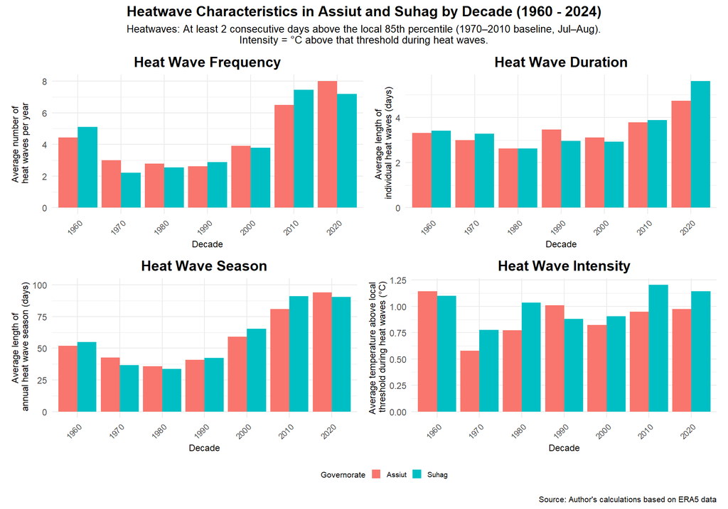

```r
#patchwork
#subset for clarity
df_sub <- heatwave_stats_long |>
  filter(name %in% c("Assiut", "Suhag"))

# Common theme modification
axis_theme <- theme(
  axis.text.x  = element_text(angle = 45, hjust = 1, size = 8),
  axis.title.x = element_text(size = 9),
  axis.title.y = element_text(size = 9)
)

# (recreate p1..p4 but include axis_theme in each)
p1 <- df_sub |>
  filter(metric == "frequency") |>
  ggplot(aes(x = factor(decade), y = value, fill = name)) +
  geom_col(position = "dodge") +
  labs(title = "Heat Wave Frequency",
       x = "Decade", y = "Average number of\n heat waves per year",
       fill = "Governorate") +
  theme_minimal() + axis_theme

p2 <- df_sub |>
  filter(metric == "mean_duration") |>
  ggplot(aes(x = factor(decade), y = value, fill = name)) +
  geom_col(position = "dodge") +
  labs(title = "Heat Wave Duration",
       x = "Decade", y = "Average length of\n individual heat waves (days)",
       fill = "Governorate") +
  theme_minimal() + axis_theme

p3 <- df_sub |>
  filter(metric == "season_length") |>
  ggplot(aes(x = factor(decade), y = value, fill = name)) +
  geom_col(position = "dodge") +
  labs(title = "Heat Wave Season",
       x = "Decade", y = "Average length of\n annual heat wave season (days)",
       fill = "Governorate") +
  scale_y_continuous(limits = c(0,100), breaks = c(0,25,50,75,100)) +
  theme_minimal() + axis_theme

p4 <- df_sub |>
  filter(metric == "mean_intensity") |>
  ggplot(aes(x = factor(decade), y = value, fill = name)) +
  geom_col(position = "dodge") +
  labs(title = "Heat Wave Intensity",
       x = "Decade",
       y = "Average temperature above local\n threshold during heat waves (°C)",
       fill = "Governorate") +
  theme_minimal() + axis_theme

# --- Combine safely and collect single legend ---
combined <- (p1 | p2) / (p3 | p4) + plot_layout(guides = "collect")

# Apply one shared theme to the whole patchwork using &
combined <- combined & theme(
  # legend
  legend.position   = "bottom",
  legend.justification = "center",
  legend.title      = element_text(size = 8),
  legend.text       = element_text(size = 7),
  legend.key.size   = unit(0.35, "cm"),
  legend.box.margin = margin(t = 0, b = 0),

  # plot annotation text sizes (use plot.title, NOT title)
  plot.title        = element_text(size = 14, face = "bold", hjust = 0.5),
  plot.subtitle     = element_text(size = 10, hjust = 0.5),
  plot.caption      = element_text(size = 8)
)

# Force a single-row legend (nice and compact)
combined <- combined & guides(fill = guide_legend(nrow = 1, byrow = TRUE))

# Add overall title / subtitle / caption
combined + plot_annotation(
  title = "Heatwave Characteristics in Assiut and Suhag by Decade (1960 - 2024)",
  subtitle = "Heatwaves: At least 2 consecutive days above the local 85th percentile (1970–2010 baseline, Jul–Aug).\nIntensity = °C above that threshold during heat waves.",
  caption = "Source: Author's calculations based on ERA5 data"
)
```

## Tropical nights

The most serious health impacts of a heat wave are often associated with high temperatures at night.

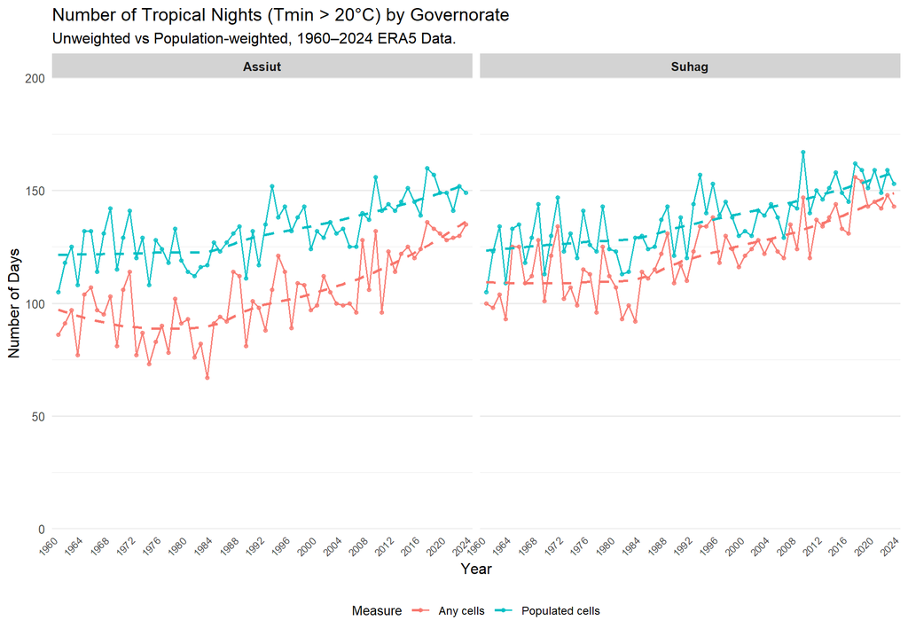

```r
tropicalnights_count <- era5_temp_df |>
  filter(name %in% c("Assiut","Suhag")) |>
  filter(year > 1960) |> #no data for 1960
  group_by(name, year) |>
  summarise(
    n_days_above20 = sum(mean_mintemp > 20, na.rm = TRUE),
    n_days_above20_popcells   = sum(mean_mintemp_pop_weighted > 20, na.rm = TRUE),
    .groups = "drop"
  ) |>
  pivot_longer(
    cols = starts_with("n_days"),
    names_to = "type",
    values_to = "n_days_above20"
  ) |>
  mutate(
    type = recode(type,
                  "n_days_above20" = "Any cells",
                  "n_days_above20_popcells"   = "Populated cells"
    )
  )

#plot
tropicalnights_count |>
  ggplot(aes(x = year, y = n_days_above20, color = type)) +
  geom_line(linewidth = 0.7, alpha = 0.9) +
  geom_point(size = 1.2, alpha = 0.7) +
  geom_smooth(se = FALSE, linetype = "dashed", linewidth = 1) +
  facet_wrap(~name) +
  scale_x_continuous(
    limits = c(1960, 2025),
    breaks = seq(1960, 2024, by = 4),
    expand = c(0, 0)
  ) +
  scale_y_continuous(
    limits = c(0, 200),  # adjust based on your data
    breaks = seq(0, 200, by = 50),
    expand = c(0, 0)
  ) +
  theme_minimal(base_size = 12) +
  labs(
    title = "Number of Tropical Nights (Tmin > 20°C) by Governorate",
    subtitle = "Unweighted vs Population-weighted, 1960–2024 ERA5 Data.",
    x = "Year",
    y = "Number of Days",
    color = "Measure"
  ) +
  theme(
    legend.position    = "bottom",
    legend.title       = element_text(size = 10),
    legend.text        = element_text(size = 9),
    strip.background   = element_rect(fill = "lightgray", color = NA),
    strip.text         = element_text(face = "bold"),
    axis.text.x        = element_text(angle = 45, hjust = 1, size = 8),
    panel.grid.major.x = element_blank(),
    panel.grid.minor.x = element_blank()
  )
```

## Hot winter days

Temperatures above 30°C during the growing season are particularly damaging to wheat and clover.

[figure not shown]

```r
days_above30_maxtemp_winterseason <- era5_temp_df |>
  filter(name %in% c("Assiut","Suhag"),
         month %in% c(11,12,1,2,3,4)) |>
  group_by(name, year) |>
  summarise(
    n_days_above30max_unweighted = sum(mean_maxtemp > 30, na.rm = TRUE),
    n_days_above30max_cropland   = sum(mean_maxtemp_cropland_weighted > 30, na.rm = TRUE),
    .groups = "drop"
  ) |>
  pivot_longer(
    cols = starts_with("n_days"),
    names_to = "type",
    values_to = "n_days_above30"
  ) |>
  mutate(
    type = recode(type,
                  "n_days_above30max_unweighted" = "Unweighted",
                  "n_days_above30max_cropland"   = "Cropland-weighted"
    )
  )

#plot 1960-2025
days_above30_maxtemp_winterseason |>
  filter(type == "Cropland-weighted") |>
  ggplot(aes(x = year, y = n_days_above30)) +
  geom_line(linewidth = 0.7, alpha = 0.9) +
  geom_point(size = 1.2, alpha = 0.7) +
  geom_smooth(se = FALSE, linetype = "dashed", linewidth = 1) +
  facet_wrap(~name) +
  scale_x_continuous(
    limits = c(1960, 2025),  # consistent with other plots
    breaks = seq(1960, 2024, by = 4),
    expand = c(0, 0)
  ) +
  scale_y_continuous(
    limits = c(0, 70),  # consistent with other plots
    breaks = seq(0,70, by = 10),
    expand = c(0, 0)
  ) +
  theme_minimal(base_size = 12) +
  labs(
    title = "Number of Winter Season Days with Max. Temp. > 30°C",
    subtitle = "Restricted to Cropland Cells - 1960–2024 (Nov. - May.) ERA5 Data.",
    x = "Year",
    y = "Number of Days",
    color = "Measure"
  ) +
  theme(
    legend.position    = "bottom",
    legend.title       = element_text(size = 10),
    legend.text        = element_text(size = 9),
    strip.background   = element_rect(fill = "lightgray", color = NA),
    strip.text         = element_text(face = "bold"),
    axis.text.x        = element_text(angle = 45, hjust = 1, size = 8),
    panel.grid.major.x = element_blank(),
    panel.grid.minor.x = element_blank()
  )
```

## Comparing three measures capturing heat stress

There are various ways to measure human exposure to extreme temperatures. Here, we distinguish three complementary approaches to measuring heat stress, each capturing different aspects of thermal exposure:

1. Measured Air temperature
2. Heat index
3. Universal Thermal Climate Index (UTCI)

The following plot compares all three measures across 2024 for the four governorates.

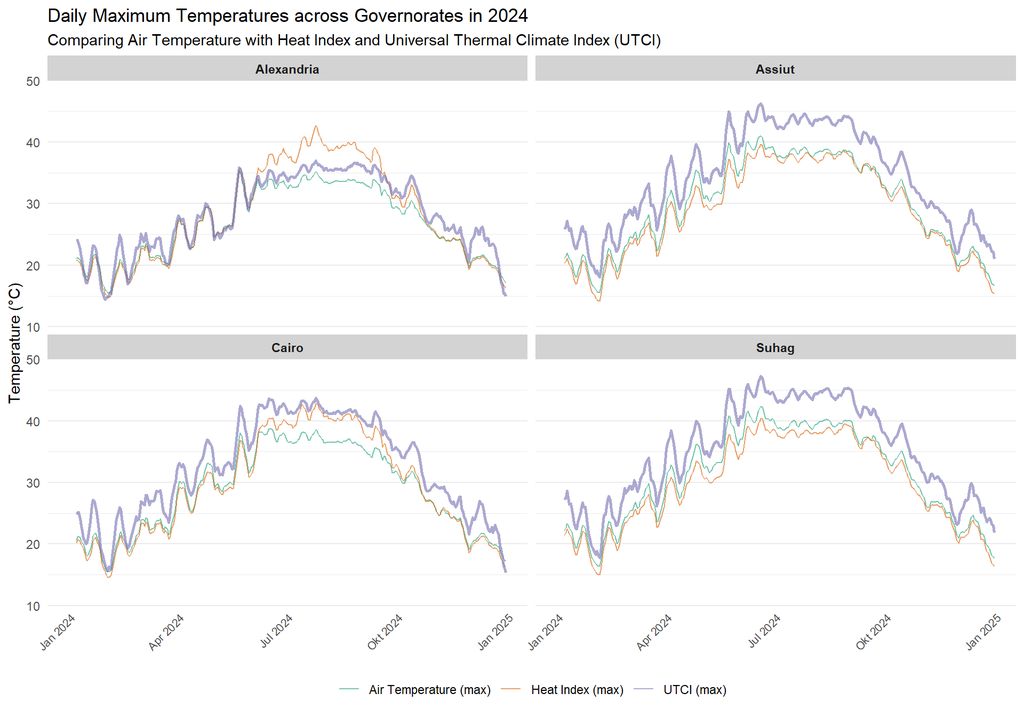

```r
temp_joined |>
  dplyr::select(name, date, mean_maxtemp, hi_dailymax, utci_dailymax) |>
  filter(date >= "2024-01-01") |>
  pivot_longer(
    cols = c(mean_maxtemp, hi_dailymax, utci_dailymax),
    names_to = "temp_measure",
    values_to = "value"
  ) |>
  mutate(
    temp_measure = factor(
      temp_measure,
      levels = c("mean_maxtemp", "hi_dailymax", "utci_dailymax"),
      labels = c(
        "Air Temperature (max)",
        "Heat Index (max)",
        "UTCI (max)"))) |>
  arrange(name, temp_measure, date) |>
  group_by(name, temp_measure) |>
  mutate(value = zoo::rollmean(value, k = 7, fill = NA, align = "right")) |>
  ggplot(aes(x = date, y = value, colour = temp_measure)) +
  geom_line(
    aes(linewidth = temp_measure == "UTCI (max)"),
    alpha = 0.6) +
  scale_linewidth_manual(values = c(`TRUE` = 1, `FALSE` = 0.4),
                         guide = "none")+
  scale_colour_manual(
    values = c(
      "Air Temperature (max)" = "#1b9e77",
      "Heat Index (max)"     = "#d95f02",
      "UTCI (max)" = "#7570b3"))+
  scale_y_continuous(
    limits = c(10, 50),  # consistent with other plots
    breaks = seq(10, 50, by = 10),
    expand = c(0, 0)) +
  labs(
    title = "Daily Maximum Temperatures across Governorates in 2024",
    subtitle = "Comparing Air Temperature with Heat Index and Universal Thermal Climate Index (UTCI)",
    x = NULL,
    y = "Temperature (°C)",
    colour = NULL) +
  theme_minimal(base_size = 11) +
  theme(legend.position = "bottom",
        strip.background = element_rect(fill = "lightgray", color = NA),
        strip.text = element_text(face = "bold"),
        axis.text.x = element_text(angle = 45, hjust = 1, size = 8),
        panel.grid.major.x = element_blank(),
        panel.grid.minor.x = element_blank())+
  facet_wrap(~ name)
```

# Precipitation Trends by Governorate

## Annual Rainfall (Population-Weighted)

This plot shows annual rainfall patterns from 1981 to 2024. The smooth trend line (red dashed) helps identify long-term patterns amid high year-to-year variability.

```r
p_rainfall <- chirps_yearly |>
  filter(name %in% key_govs) |>
  ggplot(aes(x = date, y = mean_prec_popweighted_chirps)) +
  geom_col(fill = "steelblue", color = "black", alpha = 0.7, linewidth = 0.2) +
  geom_smooth(se = FALSE, color = "darkred", linetype = "dashed", linewidth = 0.8) +
  facet_wrap(~name, ncol = 2) +
  scale_x_date(
    date_labels = "%Y",
    breaks = seq(from = as.Date("1981-01-01"),
                 to = as.Date("2024-01-01"),
                 by = "5 years")
  ) +
  theme_minimal(base_size = 12) +
  labs(
    title = "Annual Rainfall (Population-weighted) by Governorate",
    subtitle = "CHIRPS data (1981-2024)",
    x = "Year",
    y = "Rainfall (mm)"
  ) +
  theme(
    strip.background = element_rect(fill = "lightgray", color = NA),
    strip.text = element_text(face = "bold"),
    axis.text.x = element_text(angle = 45, hjust = 1),
    panel.grid.minor = element_blank()
  )

ggplotly(p_rainfall, tooltip = c("x", "y")) |>
  layout(hovermode = "closest")
```

[interactive chart not shown]

## Precipitation Statistics by Governorate

```r
summary_stats_precip <- chirps_yearly |>
  filter(name %in% key_govs) |>
  group_by(name) |>
  summarise(
    `Mean Annual Rainfall (mm)` = round(mean(mean_prec_popweighted_chirps, na.rm = TRUE), 1),
    `SD (mm)` = round(sd(mean_prec_popweighted_chirps, na.rm = TRUE), 1),
    `CV (%)` = round(sd(mean_prec_popweighted_chirps, na.rm = TRUE) /
                     mean(mean_prec_popweighted_chirps, na.rm = TRUE) * 100, 1),
    `Min Year (mm)` = round(min(mean_prec_popweighted_chirps, na.rm = TRUE), 1),
    `Max Year (mm)` = round(max(mean_prec_popweighted_chirps, na.rm = TRUE), 1),
    .groups = "drop"
  ) |>
  rename(Governorate = name)

datatable(
  summary_stats_precip,
  options = list(pageLength = 10, dom = 't'),
  caption = "Precipitation statistics for 1981-2024. CV = Coefficient of Variation (higher values indicate more variability)."
)
```

|  | Governorate | Mean Annual Rainfall (mm) | SD (mm) | CV (%) | Min Year (mm) | Max Year (mm) |
| --- | --- | --- | --- | --- | --- | --- |
| 1 | Alexandria | 162.3 | 42.6 | 26.2 | 95.3 | 285.3 |
| 2 | Assiut | 2.7 | 1.4 | 50.7 | 0.5 | 5.7 |
| 3 | Cairo | 17.8 | 7.7 | 43 | 7.2 | 43.8 |
| 4 | Suhag | 0.6 | 0.4 | 71.5 | 0.1 | 1.7 |

# Drought Trends by Governorate

## ESI

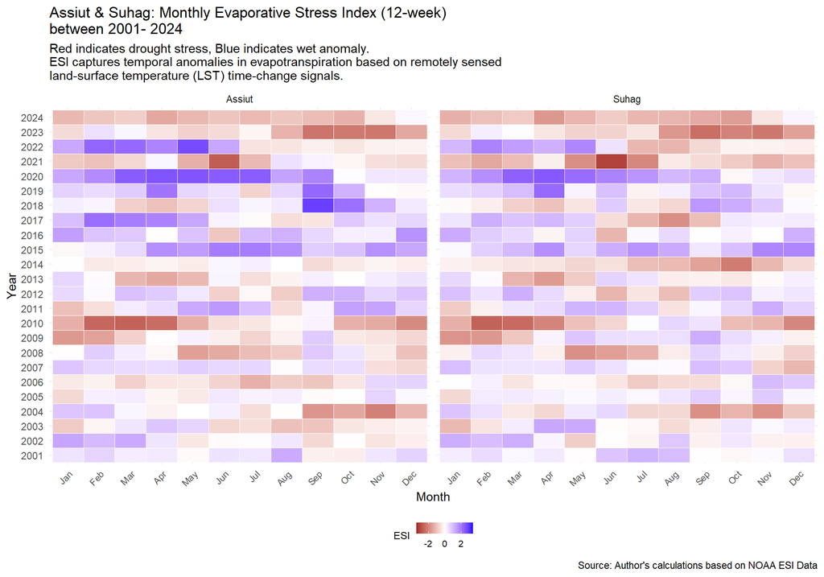

```r
esi_12week |>
  mutate(year = factor(year),
           month = factor(month, levels = 1:12, labels = month.abb)) |>
  ggplot(aes(x = month, y = year, fill = ESI)) +
  geom_tile(color = "white") +
  facet_wrap(~governorate) +
    scale_fill_gradient2(low = "brown", mid = "white", high = "blue",
                         midpoint = 0, limits = c(-3.5, 3.5),
                         name = "ESI") +
    labs(title = "Assiut & Suhag: Monthly Evaporative Stress Index (12-week)\nbetween 2001- 2024",
         subtitle = "Red indicates drought stress, Blue indicates wet anomaly.\nESI captures temporal anomalies in evapotranspiration based on remotely sensed\nland-surface temperature (LST) time-change signals.",
         caption = "Source: Author's calculations based on NOAA ESI Data",
         x = "Month", y = "Year") +
    theme_minimal()+
    theme(
      # legend
      legend.position   = "bottom",
      legend.justification = "center",
      legend.title      = element_text(size = 9),
      legend.text       = element_text(size = 8),
      legend.key.size   = unit(0.35, "cm"),
      legend.box.margin = margin(t = 0, b = 0),
      axis.text.x        = element_text(angle = 45, hjust = 1, size = 8))
```

# Key Findings

## Temperature

### 2. Regional Variations

- **Cairo and Alexandria** (Lower Egypt): Show strong warming with significant heat stress implications for dense urban populations
- **Assiut and Suhag** (Upper Egypt): Experience higher absolute temperatures and larger temperature swings

### 3. Population Weighting Matters

- Population-weighted temperatures often differ from unweighted averages by 0.2-0.5°C
- These differences reflect spatial variation in population distribution and climate within governorates
- Population-weighted measures are more relevant for assessing human exposure to climate change

## Precipitation

### 1. High Inter-Annual Variability

- Rainfall shows substantial year-to-year variation, with coefficients of variation typically exceeding 30%
- This variability poses challenges for agriculture and water resource management

### 2. Spatial Patterns

- **Alexandria**: Highest absolute rainfall among study governorates (Mediterranean climate)
- **Cairo**: Moderate rainfall with increasing aridity
- **Assiut and Suhag**: Lowest rainfall (arid/hyper-arid zones) with extreme sensitivity to precipitation changes

### 3. Extreme Events

- Both extreme dry and extreme wet years have occurred across all governorates
- Recent decades show no clear long-term trend in total annual precipitation, but high variability persists
- The timing and intensity of extreme events are critical for agricultural systems and water availability

# Methodology Notes

## Z-Scores and Climate Shocks

Z-scores normalize deviations by historical variability:

$$Z = \frac{X_{year} -
\mu}{\sigma}$$

Where: - $X_{year}$ is the annual value for a given year - $\mu$ is the mean for the baseline period - $\sigma$ is the standard deviation for the baseline period

Z-scores beyond ±2 indicate values more than 2 standard deviations from the historical norm, representing exceptional events.

## Population Weighting

Population-weighted climate variables are calculated by weighting each grid cell’s value by its population:

$$X_{weighted} = \frac{\sum_i X_i \times
Pop_i}{\sum_i Pop_i}$$

This approach better represents human exposure to climate changes than simple spatial averages.

# Data Availability

All climate data and analysis code are available in the project repository:

- **Temperature Data**: `Data/intermediate/Governorate Data/era5_temp_19602024.Rds`
- **Precipitation Data**: `Data/intermediate/Governorate Data/chirps_prec_yearly_19812024.Rds`
- **Analysis Code**: `Code/4_EDA/ClimateChange_Report.Rmd`

*Report generated on 2026-02-26 using R version 4.5.2*